# Biostat 203B Homework 3

Due Feb 21 @ 11:59PM

## Task

Your task is to develop a Shiny app that visualizes the progression of the 2019-20 Global Coronavirus Outbreak. If you are ambitious, you can also bring in visualization of other types of data, e.g., stock market and so on.

Below is some data exploration, which may help you get started. Note below code may change frequently.

## Import JHU Google Sheets into R

Johns Hopkins University (JHU) Center for Systems Science and Engineering (CSSE) kindly compiles, updates, and shares the current data on 2019-nCoV outbreak at Google Sheets: https://docs.google.com/spreadsheets/d/1UF2pSkFTURko2OvfHWWlFpDFAr1UxCBA4JLwlSP6KFo.

We can use the tidyverse package [`googlesheets4`](https://googlesheets4.tidyverse.org) to import data from Google Sheets. Because the JHU sheets are public, we don’t need authentication by tokens.

```r
# no authentication
sheets_deauth()
```

Import the `confirmed` sheet:

```r
(confirmed <- read_sheet("1UF2pSkFTURko2OvfHWWlFpDFAr1UxCBA4JLwlSP6KFo", sheet = 2))
```

```
## Reading from 'time_series_2019-ncov'
```

```
## Range "'Confirmed'"
```

```
## # A tibble: 72 x 41
##    `Province/State` `Country/Region`   Lat  Long `1/21/2020 10:0…
##    <chr>            <chr>            <dbl> <dbl>            <dbl>
##  1 Anhui            Mainland China    31.8  117.               NA
##  2 Beijing          Mainland China    40.2  116.               10
##  3 Chongqing        Mainland China    30.1  108.                5
##  4 Fujian           Mainland China    26.1  118.               NA
##  5 Gansu            Mainland China    36.1  104.               NA
##  6 Guangdong        Mainland China    23.3  113.               17
##  7 Guangxi          Mainland China    23.8  109.               NA
##  8 Guizhou          Mainland China    26.8  107.               NA
##  9 Hainan           Mainland China    19.2  110.               NA
## 10 Hebei            Mainland China    38.0  115.               NA
## # … with 62 more rows, and 36 more variables: `1/22/2020 12:00 PM` <dbl>,
## #   `1/23/2020 12:00 PM` <dbl>, `1/24/2020 12:00 AM` <dbl>, `1/24/2020 12:00
## #   PM` <dbl>, `1/25/2020 12:00 AM` <dbl>, `1/25/2020 12:00 PM` <dbl>,
## #   `1/25/2020 10:00 PM` <dbl>, `1/26/2020 11:00 AM` <dbl>, `1/26/2020 11:00
## #   PM` <dbl>, `1/27/2020 9:00 AM` <dbl>, `1/27/2020 7:00 PM` <dbl>, `1/27/2020
## #   8:30 PM` <dbl>, `1/28/2020 1:00 PM` <dbl>, `1/28/2020 6:00 PM` <dbl>,
## #   `1/28/2020 11:00 PM` <dbl>, `1/29/2020 1:30 PM` <dbl>, `1/29/2020 2:30
## #   PM` <dbl>, `1/29/2020 9:00 PM` <dbl>, `1/30/2020 11:00 AM` <dbl>,
## #   `1/31/2020 2:00 PM` <dbl>, `2/1/2020 10:00 AM` <dbl>, `2/2/2020 9:00
## #   PM` <dbl>, `2/3/2020 9:00 PM` <dbl>, `2/4/2020 9:40 AM` <dbl>, `2/4/2020
## #   10:00 PM` <dbl>, `2/5/2020 9:00 AM` <dbl>, `2/5/2020 11:00 PM` <dbl>,
## #   `2/6/2020 9:00 AM` <dbl>, `2/6/2020 2:20 PM` <dbl>, `2/7/2020 8:13
## #   PM` <dbl>, `2/7/2020 10:50 PM` <dbl>, `2/8/2020 10:04 PM` <dbl>, `2/8/20
## #   23:04` <dbl>, `02/09/2020 10:30 AM` <dbl>, `2/9/20 23:20` <dbl>, `2/10/2020
## #   11:00 AM` <dbl>
```

Import the `recovered` sheet:

```r
(recovered <- read_sheet("1UF2pSkFTURko2OvfHWWlFpDFAr1UxCBA4JLwlSP6KFo", sheet = 3))
```

```
## Reading from 'time_series_2019-ncov'
```

```
## Range "'Recovered'"
```

```
## # A tibble: 72 x 41
##    `Province/State` `Country/Region`   Lat  Long `1/21/2020 10:0…
##    <chr>            <chr>            <dbl> <dbl>            <dbl>
##  1 Anhui            Mainland China    31.8  117.               NA
##  2 Beijing          Mainland China    40.2  116.               NA
##  3 Chongqing        Mainland China    30.1  108.               NA
##  4 Fujian           Mainland China    26.1  118.               NA
##  5 Gansu            Mainland China    36.1  104.               NA
##  6 Guangdong        Mainland China    23.3  113.               NA
##  7 Guangxi          Mainland China    23.8  109.               NA
##  8 Guizhou          Mainland China    26.8  107.               NA
##  9 Hainan           Mainland China    19.2  110.               NA
## 10 Hebei            Mainland China    38.0  115.               NA
## # … with 62 more rows, and 36 more variables: `1/22/2020 12:00 PM` <dbl>,
## #   `1/23/2020 12:00 PM` <dbl>, `1/24/2020 12:00 AM` <dbl>, `1/24/2020 12:00
## #   PM` <dbl>, `1/25/2020 12:00 AM` <dbl>, `1/25/2020 12:00 PM` <dbl>,
## #   `1/25/2020 10:00 PM` <dbl>, `1/26/2020 11:00 AM` <dbl>, `1/26/2020 11:00
## #   PM` <dbl>, `1/27/2020 9:00 AM` <dbl>, `1/27/2020 7:00 PM` <dbl>, `1/27/2020
## #   8:30 PM` <dbl>, `1/28/2020 1:00 PM` <dbl>, `1/28/2020 6:00 PM` <dbl>,
## #   `1/28/2020 11:00 PM` <dbl>, `1/29/2020 1:30 PM` <dbl>, `1/29/2020 2:30
## #   PM` <dbl>, `1/29/2020 9:00 PM` <dbl>, `1/30/2020 11:00 AM` <dbl>,
## #   `1/31/2020 2:00 PM` <dbl>, `2/1/2020 10:00 AM` <dbl>, `2/2/2020 9:00
## #   PM` <dbl>, `2/3/2020 9:00 PM` <dbl>, `2/4/2020 9:40 AM` <dbl>, `2/4/2020
## #   10:00 PM` <dbl>, `2/5/2020 9:00 AM` <dbl>, `2/5/2020 11:00 PM` <dbl>,
## #   `2/6/2020 9:00 AM` <dbl>, `2/6/2020 2:20 PM` <dbl>, `2/7/2020 8:13
## #   PM` <dbl>, `2/7/2020 10:50 PM` <dbl>, `2/8/20 10:24` <dbl>, `2/8/20
## #   23:04` <dbl>, `2/9/20 10:30` <dbl>, `2/9/20 23:20` <dbl>, `2/10/2020 11:00
## #   AM` <dbl>
```

Import the `death` sheet:

```r
(death <- read_sheet("1UF2pSkFTURko2OvfHWWlFpDFAr1UxCBA4JLwlSP6KFo", sheet = 4))
```

```
## Reading from 'time_series_2019-ncov'
```

```
## Range "'Death'"
```

```
## # A tibble: 72 x 41
##    `Province/State` `Country/Region`   Lat  Long `1/21/2020 10:0…
##    <chr>            <chr>            <dbl> <dbl> <lgl>
##  1 Anhui            Mainland China    31.8  117. NA
##  2 Beijing          Mainland China    40.2  116. NA
##  3 Chongqing        Mainland China    30.1  108. NA
##  4 Fujian           Mainland China    26.1  118. NA
##  5 Gansu            Mainland China    36.1  104. NA
##  6 Guangdong        Mainland China    23.3  113. NA
##  7 Guangxi          Mainland China    23.8  109. NA
##  8 Guizhou          Mainland China    26.8  107. NA
##  9 Hainan           Mainland China    19.2  110. NA
## 10 Hebei            Mainland China    38.0  115. NA
## # … with 62 more rows, and 36 more variables: `1/22/2020 12:00 PM` <lgl>,
## #   `1/23/2020 12:00 PM` <lgl>, `1/24/2020 12:00 AM` <dbl>, `1/24/2020 12:00
## #   PM` <dbl>, `1/25/2020 12:00 AM` <dbl>, `1/25/2020 12:00 PM` <dbl>,
## #   `1/25/2020 10:00 PM` <dbl>, `1/26/2020 11:00 AM` <dbl>, `1/26/2020 11:00
## #   PM` <dbl>, `1/27/2020 9:00 AM` <dbl>, `1/27/2020 7:00 PM` <dbl>, `1/27/2020
## #   8:30 PM` <dbl>, `1/28/2020 1:00 PM` <dbl>, `1/28/2020 6:00 PM` <dbl>,
## #   `1/28/2020 11:00 PM` <dbl>, `1/29/2020 1:30 PM` <dbl>, `1/29/2020 2:30
## #   PM` <dbl>, `1/29/2020 9:00 PM` <dbl>, `1/30/2020 11:00 AM` <dbl>,
## #   `1/31/2020 2:00 PM` <dbl>, `2/1/2020 10:00 AM` <dbl>, `2/2/2020 9:00
## #   PM` <dbl>, `2/3/2020 9:00 PM` <dbl>, `2/4/2020 9:40 AM` <dbl>, `2/4/2020
## #   10:00 PM` <dbl>, `2/5/2020 9:00 AM` <dbl>, `2/5/2020 11:00 PM` <dbl>,
## #   `2/6/2020 9:00 AM` <dbl>, `2/6/2020 2:20 PM` <dbl>, `2/7/2020 8:13
## #   PM` <dbl>, `2/7/2020 10:50 PM` <dbl>, `2/8/2020 10:24 AM` <dbl>, `2/8/2020
## #   11:04 PM` <dbl>, `2/9/2020 10:30 AM` <dbl>, `2/9/2020 11:20 PM` <dbl>,
## #   `2/10/2020 11:00 AM` <dbl>
```

## Tidy data

I want to tidy data into the long format. `pivot_longer` is the modern version of `gather` function in dplyr.

```r
confirmed_long <- confirmed %>%
  pivot_longer(-(`Province/State`:Long),
               names_to = "time",
               values_to = "confirmed") %>%
  mutate(time = mdy_hm(time))
confirmed_long
```

```
## # A tibble: 2,664 x 6
##    `Province/State` `Country/Region`   Lat  Long time                confirmed
##    <chr>            <chr>            <dbl> <dbl> <dttm>                  <dbl>
##  1 Anhui            Mainland China    31.8  117. 2020-01-21 22:00:00        NA
##  2 Anhui            Mainland China    31.8  117. 2020-01-22 12:00:00         1
##  3 Anhui            Mainland China    31.8  117. 2020-01-23 12:00:00         9
##  4 Anhui            Mainland China    31.8  117. 2020-01-24 00:00:00        15
##  5 Anhui            Mainland China    31.8  117. 2020-01-24 12:00:00        15
##  6 Anhui            Mainland China    31.8  117. 2020-01-25 00:00:00        39
##  7 Anhui            Mainland China    31.8  117. 2020-01-25 12:00:00        39
##  8 Anhui            Mainland China    31.8  117. 2020-01-25 22:00:00        60
##  9 Anhui            Mainland China    31.8  117. 2020-01-26 11:00:00        60
## 10 Anhui            Mainland China    31.8  117. 2020-01-26 23:00:00        70
## # … with 2,654 more rows
```

```r
recovered_long <- recovered %>%
  pivot_longer(-(`Province/State`:Long),
               names_to = "time",
               values_to = "recovered") %>%
  mutate(time = mdy_hm(time))
recovered_long
```

```
## # A tibble: 2,664 x 6
##    `Province/State` `Country/Region`   Lat  Long time                recovered
##    <chr>            <chr>            <dbl> <dbl> <dttm>                  <dbl>
##  1 Anhui            Mainland China    31.8  117. 2020-01-21 22:00:00        NA
##  2 Anhui            Mainland China    31.8  117. 2020-01-22 12:00:00        NA
##  3 Anhui            Mainland China    31.8  117. 2020-01-23 12:00:00        NA
##  4 Anhui            Mainland China    31.8  117. 2020-01-24 00:00:00        NA
##  5 Anhui            Mainland China    31.8  117. 2020-01-24 12:00:00        NA
##  6 Anhui            Mainland China    31.8  117. 2020-01-25 00:00:00        NA
##  7 Anhui            Mainland China    31.8  117. 2020-01-25 12:00:00        NA
##  8 Anhui            Mainland China    31.8  117. 2020-01-25 22:00:00        NA
##  9 Anhui            Mainland China    31.8  117. 2020-01-26 11:00:00        NA
## 10 Anhui            Mainland China    31.8  117. 2020-01-26 23:00:00        NA
## # … with 2,654 more rows
```

```r
death_long <- death %>%
  pivot_longer(-(`Province/State`:Long),
               names_to = "time",
               values_to = "death") %>%
  mutate(time = mdy_hm(time))
death_long
```

```
## # A tibble: 2,664 x 6
##    `Province/State` `Country/Region`   Lat  Long time                death
##    <chr>            <chr>            <dbl> <dbl> <dttm>              <dbl>
##  1 Anhui            Mainland China    31.8  117. 2020-01-21 22:00:00    NA
##  2 Anhui            Mainland China    31.8  117. 2020-01-22 12:00:00    NA
##  3 Anhui            Mainland China    31.8  117. 2020-01-23 12:00:00    NA
##  4 Anhui            Mainland China    31.8  117. 2020-01-24 00:00:00    NA
##  5 Anhui            Mainland China    31.8  117. 2020-01-24 12:00:00    NA
##  6 Anhui            Mainland China    31.8  117. 2020-01-25 00:00:00    NA
##  7 Anhui            Mainland China    31.8  117. 2020-01-25 12:00:00    NA
##  8 Anhui            Mainland China    31.8  117. 2020-01-25 22:00:00    NA
##  9 Anhui            Mainland China    31.8  117. 2020-01-26 11:00:00    NA
## 10 Anhui            Mainland China    31.8  117. 2020-01-26 23:00:00    NA
## # … with 2,654 more rows
```

```r
ncov_tbl <- confirmed_long %>%
  left_join(recovered_long) %>%
  left_join(death_long)
```

[output not shown]

```r
ncov_tbl %>% print(width = Inf)
```

```
## # A tibble: 2,664 x 8
##    `Province/State` `Country/Region`   Lat  Long time                confirmed
##    <chr>            <chr>            <dbl> <dbl> <dttm>                  <dbl>
##  1 Anhui            Mainland China    31.8  117. 2020-01-21 22:00:00        NA
##  2 Anhui            Mainland China    31.8  117. 2020-01-22 12:00:00         1
##  3 Anhui            Mainland China    31.8  117. 2020-01-23 12:00:00         9
##  4 Anhui            Mainland China    31.8  117. 2020-01-24 00:00:00        15
##  5 Anhui            Mainland China    31.8  117. 2020-01-24 12:00:00        15
##  6 Anhui            Mainland China    31.8  117. 2020-01-25 00:00:00        39
##  7 Anhui            Mainland China    31.8  117. 2020-01-25 12:00:00        39
##  8 Anhui            Mainland China    31.8  117. 2020-01-25 22:00:00        60
##  9 Anhui            Mainland China    31.8  117. 2020-01-26 11:00:00        60
## 10 Anhui            Mainland China    31.8  117. 2020-01-26 23:00:00        70
##    recovered death
##        <dbl> <dbl>
##  1        NA    NA
##  2        NA    NA
##  3        NA    NA
##  4        NA    NA
##  5        NA    NA
##  6        NA    NA
##  7        NA    NA
##  8        NA    NA
##  9        NA    NA
## 10        NA    NA
## # … with 2,654 more rows
```

## Mapping China provinces

Some useful resources for mapping:  
- The book [*Geocomputation with R*](https://geocompr.robinlovelace.net). Especially [Chapter 8 Making Maps with R](https://geocompr.robinlovelace.net/adv-map.html).  
- The book [*An Introduction to Spatial Analysis and Mapping in R*](https://bookdown.org/lexcomber/brunsdoncomber2e/).

### Use mapdata - **MAP IS TOO OLD**

The package `mapdata` contains a data `china`. But the map seems out-dated. For example, Chongqing is sill a part of Sichuan province in this map.

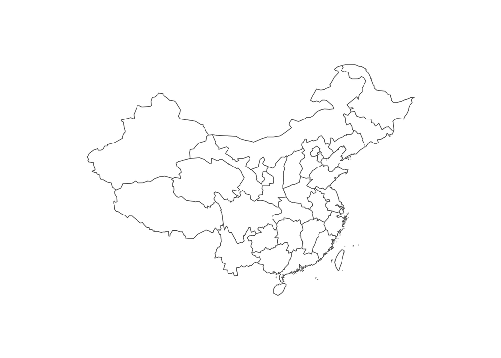

```r
suppressMessages(library(mapdata))
map("china", col = "gray40", ylim = c(18,54))
```

### Use GADM data - **THIS IS VERY SLOW**

```r
library(sf)
library(tidyverse)
gadm36_CHN_1_sf <- readRDS("gadm36_CHN_0_sf.rds")
ggplot(data = gadm36_CHN_1_sf) +
  geom_sf()
```

```r
library("GADMTools")
map <- gadm_sp_loadCountries("CHN", level = 1, basefile = "./")
gadm_plot(map) + theme_light()
```

### Use shapefile from GADM - **THIS IS VERY SLOW**

```r
library(maptools)
map <- rgdal::readOGR("gadm36_CHN_shp/gadm36_CHN_1.shp")
plot(map)
```

### Use maptools and GIS data from China

Donwload China GIS data from [here](https://uploads.cosx.org/2009/07/chinaprovinceborderdata_tar_gz.zip), unzip, and put in the working directory.

```bash
ls -l bou2_4p.*
```

```
## -rwxrwxrwx@ 1 huazhou  staff    86283 Apr 10  1999 bou2_4p.dbf
## -rwxrwxrwx@ 1 huazhou  staff  1508752 Apr 10  1999 bou2_4p.shp
## -rwxrwxrwx@ 1 huazhou  staff     7500 Apr 10  1999 bou2_4p.shx
```

Read in the shape file into simple feature (SF) format:

```r
library(sf)
chn_map <- st_read("./bou2_4p.shp", as_tibble = TRUE) %>%
  mutate(NAME = iconv(NAME, from = "GBK"),
         BOU2_4M_ = as.integer(BOU2_4M_),
         BOU2_4M_ID = as.integer(BOU2_4M_ID)) %>%
  mutate(NAME = str_replace_na(NAME, replacement = "澳门特别行政区"))
class(chn_map)
```

```
## [1] "sf"         "tbl_df"     "tbl"        "data.frame"
```

`ggplot2` can plot SF data using `geom_sf` function:

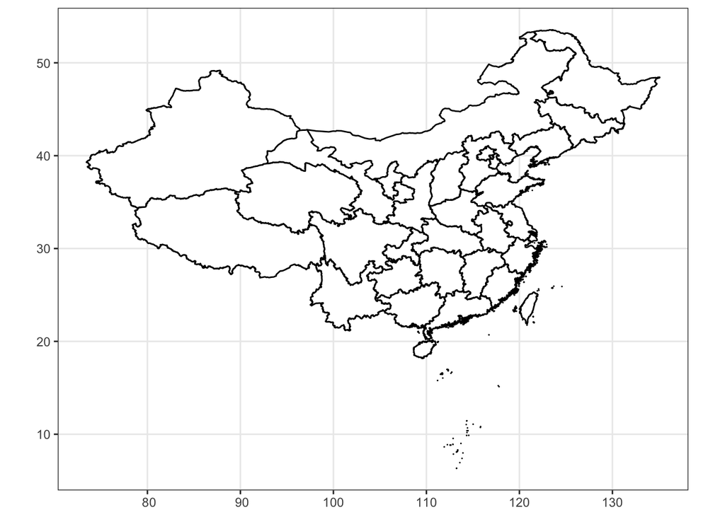

```r
chn_map %>%
  ggplot() +
  geom_sf(color = "black", fill = "white") +
  theme_bw() # better for maps
```

```r
chn_map %>% print(width = Inf)
```

```
## Simple feature collection with 925 features and 7 fields
## geometry type:  POLYGON
## dimension:      XY
## bbox:           xmin: 73.44696 ymin: 6.318641 xmax: 135.0858 ymax: 53.55793
## epsg (SRID):    NA
## proj4string:    NA
## # A tibble: 925 x 8
##      AREA PERIMETER BOU2_4M_ BOU2_4M_ID ADCODE93 ADCODE99 NAME
##  *  <dbl>     <dbl>    <int>      <int>    <int>    <int> <chr>
##  1  54.4     68.5          2         23   230000   230000 黑龙江省
##  2 129.     130.           3         15   150000   150000 内蒙古自治区
##  3 176.      84.9          4         65   650000   650000 新疆维吾尔自治区
##  4  21.3     41.2          5         22   220000   220000 吉林省
##  5  15.6     38.4          6         21   210000   210000 辽宁省
##  6  41.5     76.8          7         62   620000   620000 甘肃省
##  7  19.5     44.9          8         13   130000   130000 河北省
##  8   1.73     8.50         9         11   110000   110000 北京市
##  9   0        0.088       10        292   210000   210000 辽宁省
## 10   0        0.047       11        292   210000   210000 辽宁省
##                                                                         geometry
##  *                                                                     <POLYGON>
##  1 ((121.4884 53.33265, 121.4995 53.33601, 121.5184 53.33919, 121.5391 53.34172…
##  2 ((121.4884 53.33265, 121.4974 53.32104, 121.5004 53.31389, 121.5316 53.30765…
##  3 ((96.38329 42.72696, 96.35991 42.70969, 96.09664 42.59967, 96.05975 42.39874…
##  4 ((123.171 46.24668, 123.2186 46.26945, 123.2394 46.27015, 123.2881 46.24924,…
##  5 ((123.6902 43.37677, 123.705 43.38155, 123.7156 43.43486, 123.7683 43.47599,…
##  6 ((96.38329 42.72696, 96.38308 42.72533, 96.39072 42.72654, 96.39691 42.72712…
##  7 ((116.9304 42.41145, 116.9627 42.42617, 116.9878 42.42606, 117.0181 42.45633…
##  8 ((117.496 40.66534, 117.4992 40.64039, 117.4938 40.63514, 117.4757 40.63649,…
##  9 ((121.7627 41.0012, 121.773 41.00534, 121.7758 41.01176, 121.7749 41.02047, …
## 10 ((121.7979 40.99618, 121.7931 40.98311, 121.7855 40.97898, 121.7834 40.98471…
## # … with 915 more rows
```

There are about 34 provinces in China, why there are 925 areas?

```r
chn_map %>%
  count(NAME) %>%
  print(n = Inf)
```

```
## Simple feature collection with 34 features and 2 fields
## geometry type:  GEOMETRY
## dimension:      XY
## bbox:           xmin: 73.44696 ymin: 6.318641 xmax: 135.0858 ymax: 53.55793
## epsg (SRID):    NA
## proj4string:    NA
## # A tibble: 34 x 3
##    NAME             n                                                   geometry
##  * <chr>        <int>                                                 <GEOMETRY>
##  1 上海市          12 MULTIPOLYGON (((121.414 30.6952, 121.415 30.69756, 121.41…
##  2 云南省           1 POLYGON ((98.65588 28.83075, 98.65788 28.8333, 98.66165 2…
##  3 内蒙古自治区     1 POLYGON ((121.4884 53.33265, 121.4974 53.32104, 121.5004 …
##  4 北京市           1 POLYGON ((117.496 40.66534, 117.4992 40.64039, 117.4938 4…
##  5 台湾省          57 MULTIPOLYGON (((120.8155 21.75681, 120.8174 21.75765, 120…
##  6 吉林省           1 POLYGON ((123.171 46.24668, 123.2186 46.26945, 123.2394 4…
```

[output cut: 28 more lines]

These are the provinces available from the JHU sheets.

```r
ncov_tbl %>%
  filter(`Country/Region` %in% c("Mainland China", "Macau", "Hong Kong", "Taiwan")) %>%
  distinct(`Province/State`, `Country/Region`) %>%
  print(n = Inf)
```

```
## # A tibble: 34 x 2
##    `Province/State` `Country/Region`
##    <chr>            <chr>
##  1 Anhui            Mainland China
##  2 Beijing          Mainland China
##  3 Chongqing        Mainland China
##  4 Fujian           Mainland China
##  5 Gansu            Mainland China
##  6 Guangdong        Mainland China
##  7 Guangxi          Mainland China
##  8 Guizhou          Mainland China
##  9 Hainan           Mainland China
## 10 Hebei            Mainland China
## 11 Heilongjiang     Mainland China
## 12 Henan            Mainland China
```

[output cut: 22 more lines]

We create a function to translate Chinese province name to English.

```r
translate <- function(x) {
  sapply(x, function(chn_name) {
    if (str_detect(chn_name, "澳门")) {
      eng_name <- "Macau"
    } else if (str_detect(chn_name, "台湾")) {
      eng_name <- "Taiwan"
    } else if (str_detect(chn_name, "上海")) {
      eng_name <- "Shanghai"
    } else if (str_detect(chn_name, "云南")) {
      eng_name <- "Yunnan"
    } else if (str_detect(chn_name, "内蒙古")) {
      eng_name <- "Inner Mongolia"
    } else if (str_detect(chn_name, "北京")) {
      eng_name <- "Beijing"
    } else if (str_detect(chn_name, "台湾")) {
      eng_name <- "Taiwan"
    } else if (str_detect(chn_name, "吉林")) {
      eng_name <- "Jilin"
    } else if (str_detect(chn_name, "四川")) {
      eng_name <- "Sichuan"
    } else if (str_detect(chn_name, "天津")) {
      eng_name <- "Tianjin"
    } else if (str_detect(chn_name, "宁夏")) {
      eng_name <- "Ningxia"
    } else if (str_detect(chn_name, "安徽")) {
      eng_name <- "Anhui"
    } else if (str_detect(chn_name, "山东")) {
      eng_name <- "Shandong"
    } else if (str_detect(chn_name, "山西")) {
      eng_name <- "Shanxi"
    } else if (str_detect(chn_name, "广东")) {
      eng_name <- "Guangdong"
    } else if (str_detect(chn_name, "广西")) {
      eng_name <- "Guangxi"
    } else if (str_detect(chn_name, "新疆")) {
      eng_name <- "Xinjiang"
    } else if (str_detect(chn_name, "江苏")) {
      eng_name <- "Jiangsu"
    } else if (str_detect(chn_name, "江西")) {
      eng_name <- "Jiangxi"
    } else if (str_detect(chn_name, "河北")) {
      eng_name <- "Hebei"
    } else if (str_detect(chn_name, "河南")) {
      eng_name <- "Henan"
    } else if (str_detect(chn_name, "浙江")) {
      eng_name <- "Zhejiang"
    } else if (str_detect(chn_name, "海南")) {
      eng_name <- "Hainan"
    } else if (str_detect(chn_name, "湖北")) {
      eng_name <- "Hubei"
    } else if (str_detect(chn_name, "湖南")) {
      eng_name <- "Hunan"
    } else if (str_detect(chn_name, "甘肃")) {
      eng_name <- "Gansu"
    } else if (str_detect(chn_name, "福建")) {
      eng_name <- "Fujian"
    } else if (str_detect(chn_name, "西藏")) {
      eng_name <- "Tibet"
    } else if (str_detect(chn_name, "贵州")) {
      eng_name <- "Guizhou"
    } else if (str_detect(chn_name, "辽宁")) {
      eng_name <- "Liaoning"
    } else if (str_detect(chn_name, "重庆")) {
      eng_name <- "Chongqing"
    } else if (str_detect(chn_name, "陕西")) {
      eng_name <- "Shanxi"
    } else if (str_detect(chn_name, "青海")) {
      eng_name <- "Qinghai"
    } else if (str_detect(chn_name, "香港")) {
      eng_name <- "Hong Kong"
    } else if (str_detect(chn_name, "黑龙江")) {
      eng_name <- "Heilongjiang"
    } else {
      eng_name <- chn_name # don't translate if no correspondence
    }
    return(eng_name)
  })
}
```

Create a new variable `NAME_ENG`:

```r
chn_prov <- chn_map %>%
  count(NAME) %>%
  mutate(NAME_ENG = translate(NAME))
chn_prov %>% print(n = Inf)
```

```
## Simple feature collection with 34 features and 3 fields
## geometry type:  GEOMETRY
## dimension:      XY
## bbox:           xmin: 73.44696 ymin: 6.318641 xmax: 135.0858 ymax: 53.55793
## epsg (SRID):    NA
## proj4string:    NA
## # A tibble: 34 x 4
##    NAME           n                                          geometry NAME_ENG
##  * <chr>      <int>                                        <GEOMETRY> <chr>
##  1 上海市        12 MULTIPOLYGON (((121.414 30.6952, 121.415 30.6975… Shanghai
##  2 云南省         1 POLYGON ((98.65588 28.83075, 98.65788 28.8333, 9… Yunnan
##  3 内蒙古自治区…     1 POLYGON ((121.4884 53.33265, 121.4974 53.32104, … Inner Mon…
##  4 北京市         1 POLYGON ((117.496 40.66534, 117.4992 40.64039, 1… Beijing
##  5 台湾省        57 MULTIPOLYGON (((120.8155 21.75681, 120.8174 21.7… Taiwan
##  6 吉林省         1 POLYGON ((123.171 46.24668, 123.2186 46.26945, 1… Jilin
```

[output cut: 28 more lines]

## Plotting 2019-nCoV incidence

Confirmed cases:

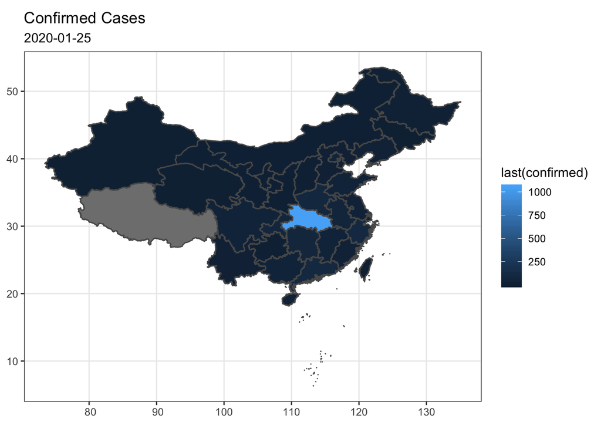

```r
plotdate <- "2020-01-25"
ncov_tbl %>%
  filter(`Country/Region` %in% c("Mainland China", "Macau", "Hong Kong", "Taiwan")) %>%
  mutate(date = date(time)) %>%
  group_by(`Province/State`, date) %>%
  arrange(time) %>%
  summarise(last(confirmed)) %>%
  filter(date == plotdate) %>%
  right_join(chn_prov, by = c("Province/State" = "NAME_ENG")) %>%
  ggplot() +
  geom_sf(mapping = aes(fill = `last(confirmed)`, geometry = geometry)) +
  theme_bw() +
  labs(title = "Confirmed Cases", subtitle = plotdate)
```